# `clust-learn` - Module 1: Data Preprocessing

Results from ML models are only as good as the data they are trained on. This is the reason why data preprocessing is essential to obtain robust and reliable results.

This guide shows you how to use the `data_preprocessing` module of the `clust-learn` package to perform missing data assessment and imputation, and outlier detection. The imputation is performed running every step of the methodology at a time.

## 0. Setup

```python
import numpy as np
import pandas as pd

from clearn.data_preprocessing import *

pd.set_option('display.max_columns', None)
```

## 1. Data loading

```python
df = pd.read_csv('data/pisa_spain_sample_v2.csv')
df.head()
```

|  | stu_original_order | ST004D01T | IMMIG | REPEAT | AGE | PAREDINT | BMMJ1 | BFMJ2 | HISEI | DURECEC | BSMJ | MMINS | LMINS | SMINS | TMINS | FCFMLRTY | SCCHANGE | CHANGE | STUBMI | ESCS | UNDREM | METASUM | METASPAM | ICTHOME | ICTSCH | HOMEPOS | CULTPOSS | HEDRES | WEALTH | … |
| --- | --- | --- | --- | --- | --- | --- | --- | --- | --- | --- | --- | --- | --- | --- | --- | --- | --- | --- | --- | --- | --- | --- | --- | --- | --- | --- | --- | --- | --- | --- |
| 0 | 8270 | 2.0 | 1.0 | 0.0 | 15.75 | 12.0 | 54.55 | 29.18 | 54.55 | 2.0 | 51.50 | 220.0 | 220.0 | 0.0 | 1650.0 | 5.0 | NaN | NaN | NaN | -0.8158 | 0.45 | 0.59 | -1.41 | NaN | NaN | -1.3356 | -0.7075 | -1.0118 | -0.8567 | … |
| 1 | 18270 | 1.0 | 3.0 | 1.0 | 15.75 | 3.0 | NaN | NaN | NaN | 3.0 | 75.13 | 220.0 | 220.0 | 110.0 | 1650.0 | NaN | NaN | NaN | NaN | -2.7449 | -0.94 | -1.34 | 1.33 | NaN | NaN | -0.4448 | -0.5491 | -0.6853 | 0.1307 | … |
| 2 | 31863 | 2.0 | 1.0 | 1.0 | 16.08 | 14.5 | 46.76 | 17.56 | 46.76 | NaN | NaN | 220.0 | 165.0 | 110.0 | 1760.0 | 4.0 | 0.0 | 0.0 | 23.39 | 0.0050 | 1.15 | 0.59 | 1.33 | 9.0 | 5.0 | 0.0075 | 0.5143 | -0.6853 | -0.0741 | … |
| 3 | 31473 | 1.0 | 1.0 | 0.0 | 15.67 | 14.5 | 29.73 | 42.30 | 42.30 | 3.0 | 70.10 | 200.0 | 200.0 | 150.0 | 1500.0 | 3.0 | 0.0 | 0.0 | 19.68 | -0.3694 | 1.15 | 0.21 | 0.87 | 9.0 | 8.0 | -0.6764 | -0.8404 | -0.6853 | -0.3370 | … |
| 4 | 19454 | 1.0 | 1.0 | 0.0 | 15.83 | 14.5 | 25.04 | NaN | 25.04 | 3.0 | NaN | NaN | NaN | NaN | NaN | 12.0 | 0.0 | 0.0 | 31.60 | -0.4287 | NaN | NaN | NaN | 8.0 | 4.0 | -0.0394 | 1.0094 | -0.6853 | -0.2160 | … |

```python
df.shape
```

```
(5000, 82)
```

We separate numerical and categorical variables.

```python
num_vars = ['AGE', 'PAREDINT', 'BMMJ1',
       'BFMJ2', 'HISEI', 'DURECEC', 'BSMJ', 'MMINS',
       'LMINS', 'SMINS', 'TMINS', 'FCFMLRTY', 'SCCHANGE', 'CHANGE', 'STUBMI',
       'ESCS', 'UNDREM', 'METASUM', 'METASPAM', 'ICTHOME', 'ICTSCH', 'HOMEPOS',
       'CULTPOSS', 'HEDRES', 'WEALTH', 'ICTRES', 'DISCLIMA', 'TEACHSUP',
       'DIRINS', 'PERFEED', 'EMOSUPS', 'STIMREAD', 'ADAPTIVITY', 'TEACHINT',
       'JOYREAD', 'SCREADCOMP', 'SCREADDIFF', 'PERCOMP', 'PERCOOP', 'ATTLNACT',
       'COMPETE', 'WORKMAST', 'GFOFAIL', 'EUDMO', 'SWBP', 'RESILIENCE',
       'MASTGOAL', 'GCSELFEFF', 'GCAWARE', 'ATTIMM', 'INTCULT', 'PERSPECT',
       'COGFLEX', 'RESPECT', 'AWACOM', 'GLOBMIND', 'DISCRIM', 'BELONG',
       'BEINGBULLIED', 'ENTUSE', 'HOMESCH', 'USESCH', 'INTICT', 'COMPICT',
       'AUTICT', 'SOIAICT', 'ICTCLASS', 'ICTOUTSIDE', 'INFOCAR', 'INFOJOB1',
       'INFOJOB2', 'FLCONFIN', 'FLCONICT', 'FLSCHOOL', 'FLFAMILY', 'BODYIMA',
       'SOCONPA']
cat_vars = ['ST004D01T', 'IMMIG', 'REPEAT']
```

## 3. Data preprocessing

### 3.1. Missing values

#### 3.1.1. Missung value assessment

```python
print('Missing values:', df.isnull().sum().sum(), f'({df.isnull().sum().sum()*100/df.size}%)')
```

```
Missing values: 49245 (12.010975609756098%)
```

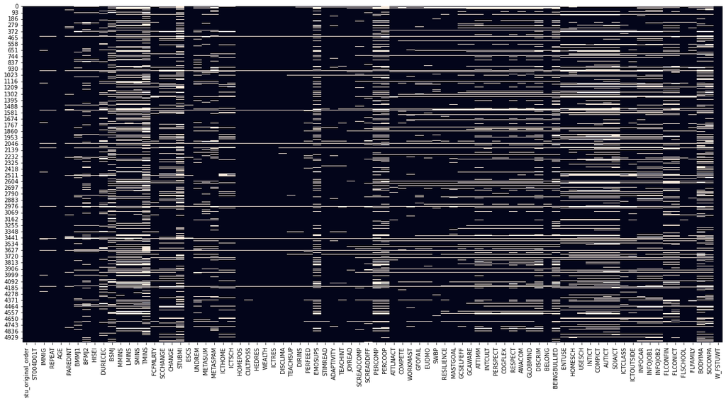

```python
missing_values_heatmap(df) #, output_path='PATH.jpg')
```

```python
compute_missing(df).head(10)
```

|  | var_name | missing |
| --- | --- | --- |
| 14 | TMINS | 38.44 |
| 69 | SOIAICT | 29.96 |
| 18 | STUBMI | 28.94 |
| 68 | AUTICT | 28.12 |
| 67 | COMPICT | 27.42 |
| 79 | BODYIMA | 26.74 |
| 42 | PERCOOP | 26.48 |
| 80 | SOCONPA | 25.46 |
| 13 | SMINS | 25.26 |
| 62 | BEINGBULLIED | 24.76 |

#### 3.1.2. Data imputation. Step-by-step approach

We use the functions available to run every step of the methodology independently. This allows the user to check the result of every step.

```python
# Note this is essential for reproducibility. Restart kernel every time you run the analysis for getting same results
np.random.seed(42)
```

We start by calculating the imputation pairs for one-to-one model-based imputation.

```python
ip = imputation_pairs(df, num_vars, cat_vars)
df_imp_01 = impute_missing_values_with_highly_related_pairs(df, ip, num_vars, cat_vars)
```

```
Imputing with linear regression HOMEPOS -> WEALTH
Imputing with linear regression HOMEPOS -> ICTRES
Imputing with linear regression HOMEPOS -> ESCS
Imputing with linear regression ESCS -> PAREDINT
Imputing with linear regression ESCS -> HISEI
Imputing with linear regression ESCS -> BMMJ1
Imputing with linear regression HISEI -> BFMJ2
Imputing with linear regression SCCHANGE -> CHANGE
Imputing with linear regression FLCONFIN -> FLCONICT
Imputing with linear regression MMINS -> LMINS
```

```python
ip
```

|  | var1 | var2 | missing_var1 | missing_var2 |
| --- | --- | --- | --- | --- |
| 0 | WEALTH | HOMEPOS | 1.30 | 1.28 |
| 1 | ICTRES | HOMEPOS | 1.40 | 1.28 |
| 2 | ESCS | HOMEPOS | 1.94 | 1.28 |
| 3 | PAREDINT | ESCS | 3.36 | 1.94 |
| 4 | HISEI | ESCS | 4.66 | 1.94 |
| 5 | BMMJ1 | ESCS | 9.18 | 1.94 |
| 6 | BFMJ2 | HISEI | 12.68 | 4.66 |
| 7 | CHANGE | SCCHANGE | 13.12 | 12.88 |
| 8 | FLCONICT | FLCONFIN | 21.28 | 18.76 |
| 9 | LMINS | MMINS | 24.52 | 24.42 |

```python
print(df.shape, '>>', df.isnull().sum().sum())
print(df_imp_01.shape, '>>', df_imp_01.isnull().sum().sum())
```

```
(5000, 82) >> 49245
(5000, 82) >> 47791
```

```python
compute_missing(df)
```

|  | var_name | missing |
| --- | --- | --- |
| 14 | TMINS | 38.44 |
| 69 | SOIAICT | 29.96 |
| 18 | STUBMI | 28.94 |
| 68 | AUTICT | 28.12 |
| 67 | COMPICT | 27.42 |
| ... | ... | ... |
| 25 | HOMEPOS | 1.28 |
| 0 | stu_original_order | 0.00 |
| 1 | ST004D01T | 0.00 |
| 4 | AGE | 0.00 |
| 81 | W_FSTUWT | 0.00 |

82 rows × 2 columns

Let's visualize the imputation pair scatter plots.

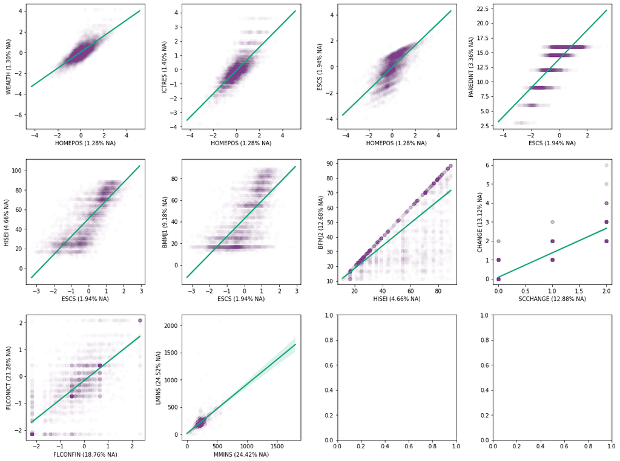

```python
plot_imputation_pairs_scatter(df, ip, scatter_kws=dict(color='#7F3C8D', alpha=0.01), line_kws=dict(color='#11A579'))
```

Next, we calculate variable clusters for hot deck imputation.

```python
mi_scores = mutual_information_pair_scores(df_imp_01, num_vars, cat_vars)
nodes, edges, comp = variable_graph_partitioning(mi_scores, thres=0.05)
```

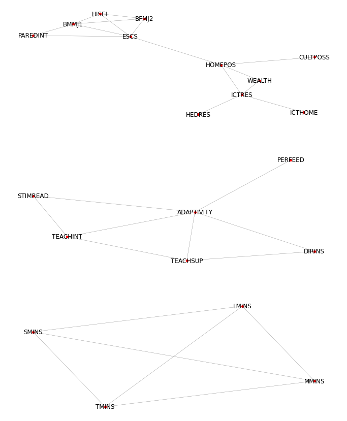

```python
plot_variable_graph_partitioning_components(edges, comp[:3]) #, output_path='PATH.jpg')
```

```python
df_imp_02 = hot_deck_imputation(df_imp_01, num_vars+cat_vars, k=8, partitions=list(np.array(comp)[np.array(list(map(len, comp))) >= 4]))
```

```
Partition: ['BFMJ2', 'BMMJ1', 'CULTPOSS', 'ESCS', 'HEDRES', 'HISEI', 'HOMEPOS', 'ICTHOME', 'ICTRES', 'PAREDINT', 'WEALTH']
Remaining missing values 47436
Partition: ['ADAPTIVITY', 'DIRINS', 'PERFEED', 'STIMREAD', 'TEACHINT', 'TEACHSUP']
Remaining missing values 47272
Partition: ['LMINS', 'MMINS', 'SMINS', 'TMINS']
Remaining missing values 46488
```

```python
print(df.shape, '>>', df.isnull().sum().sum())
print(df_imp_01.shape, '>>', df_imp_01.isnull().sum().sum())
print(df_imp_02.shape, '>>', df_imp_02.isnull().sum().sum())
```

```
(5000, 82) >> 49245
(5000, 82) >> 47791
(5000, 82) >> 46488
```

Before imputing the remaining missing values, we remove those observations with more than 1/3 of the data missing, to ensure there is enough information to consider two observations as nearest neighbors.

```python
df_imp_03 = df_imp_02[df_imp_02.isnull().sum(1) < df_imp_02.shape[1] *0.33]
```

```python
print(df.shape, '>>', df.isnull().sum().sum())
print(df_imp_01.shape, '>>', df_imp_01.isnull().sum().sum())
print(df_imp_02.shape, '>>', df_imp_02.isnull().sum().sum())
print(df_imp_03.shape, '>>', df_imp_03.isnull().sum().sum())
```

```
(5000, 82) >> 49245
(5000, 82) >> 47791
(5000, 82) >> 46488
(4556, 82) >> 27566
```

```python
df_imp_04 = hot_deck_imputation(df_imp_03, num_vars + cat_vars, k=8)
```

```
Partition: ['ADAPTIVITY', 'AGE', 'ATTIMM', 'ATTLNACT', 'AUTICT', 'AWACOM', 'BEINGBULLIED', 'BELONG', 'BFMJ2', 'BMMJ1', 'BODYIMA', 'BSMJ', 'CHANGE', 'COGFLEX', 'COMPETE', 'COMPICT', 'CULTPOSS', 'DIRINS', 'DISCLIMA', 'DISCRIM', 'DURECEC', 'EMOSUPS', 'ENTUSE', 'ESCS', 'EUDMO', 'FCFMLRTY', 'FLCONFIN', '…
Remaining missing values 0
```

```python
print(df.shape, '>>', df.isnull().sum().sum())
print(df_imp_01.shape, '>>', df_imp_01.isnull().sum().sum())
print(df_imp_02.shape, '>>', df_imp_02.isnull().sum().sum())
print(df_imp_03.shape, '>>', df_imp_03.isnull().sum().sum())
print(df_imp_04.shape, '>>', df_imp_04.isnull().sum().sum())
```

```
(5000, 82) >> 49245
(5000, 82) >> 47791
(5000, 82) >> 46488
(4556, 82) >> 27566
(4556, 82) >> 0
```

Let's now check that all values have been imputed and that the resulting variable distributions after imputation look similar to the original ones.

```python
compute_missing(df_imp_04)
```

|  | var_name | missing |
| --- | --- | --- |
| 0 | stu_original_order | 0.0 |
| 61 | BELONG | 0.0 |
| 59 | GLOBMIND | 0.0 |
| 58 | AWACOM | 0.0 |
| 57 | RESPECT | 0.0 |
| ... | ... | ... |
| 26 | CULTPOSS | 0.0 |
| 25 | HOMEPOS | 0.0 |
| 24 | ICTSCH | 0.0 |
| 23 | ICTHOME | 0.0 |
| 81 | W_FSTUWT | 0.0 |

82 rows × 2 columns

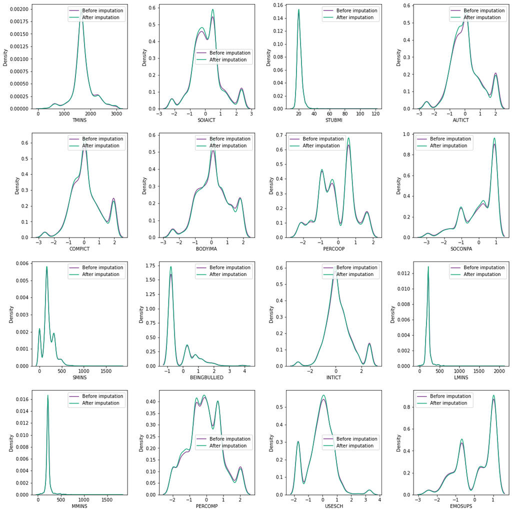

```python
plot_imputation_distribution_assessment(df.loc[df_imp_04.index], df_imp_04, list(compute_missing(df).head(16)['var_name']))
```

Save the data frame with imputed values.

```python
#df_imp_04.to_csv('data/pisa_spain_sample_v2_manual_imputartion_output.csv', index=False)
```

### 3.2. Outlier detection

```python
clean, outliers = remove_outliers(df_imp_04, num_vars+cat_vars)
```

```python
print(df.shape, '>>', df.isnull().sum().sum())
print(df_imp_01.shape, '>>', df_imp_01.isnull().sum().sum())
print(df_imp_02.shape, '>>', df_imp_02.isnull().sum().sum())
print(df_imp_03.shape, '>>', df_imp_03.isnull().sum().sum())
print(df_imp_04.shape, '>>', df_imp_04.isnull().sum().sum())
print(clean.shape, '>>', clean.isnull().sum().sum())
```

```
(5000, 82) >> 49245
(5000, 82) >> 47791
(5000, 82) >> 46488
(4556, 82) >> 27566
(4556, 82) >> 0
(4231, 82) >> 0
```

```python
#clean.to_csv('data/pisa_spain_sample_v2_processed_manual_output.csv', index=False)
#outliers.to_csv('data/pisa_spain_sample_v2_outliers_manual_output.csv', index=False)
```